# Relatório

# Análise longitudinal dos dados (GEE)

O método de equações de estimação generalizado é uma alternativa para a modelagem de dados longitudinais.

Essa técnica de modelagem requer a indicação de uma estrutura de correlação entre o tempo e estima o efeito médio populacional das variáveis explicativas levando em consideração a correlação interna de cada paciente.

O algorítmo obtem a estimativa dos coeficientes $\beta$ através da maximização da equação abaixo em $\beta$:

$$U(\tilde\beta)=\sum\limits_{i=1}^n \frac{\partial\mu_{ij}}{\partial \beta_p}V_i^{-1}\{Y_i-\mu_i(\tilde\beta)\}$$
Onde:

- $\mu_{ij}$ é o valor da variável explicativa do indivíduo $i$ no tempo $j$.
- $\beta_p, \ p = 1,\ldots,k$ são os coeficientes das variáveis explicativas
- $V_i$ é a estrutura de correlaçãodo tempo.

```r
require(geepack)
dados_scaled <- dados2  %>% mutate(Plaquetas=log2(Plaquetas),Leucocitos=log2(Leucocitos),
                                       TGO=log2(TGO),TGP=log2(TGP)) %>% select(-dt_inic) %>% ungroup %>%
  mutate(pac = as.factor(pac)) %>%
  select(Ht,TGO,pac,dt_sup,Plaquetas,TARGET,ICTERICIA,dt_ate_inter) %>%
  group_by(pac) %>% mutate(number = row_number()) %>%
  drop_na()

ajuste_gee<- geeglm(TARGET~Plaquetas+Ht+TGO+ICTERICIA,id=pac, data=dados_scaled, family=binomial(link='logit'),waves = dt_sup,
                           corstr='independence', std.err="san.se")


summary(ajuste_gee)
```

```
##
## Call:
## geeglm(formula = TARGET ~ Plaquetas + Ht + TGO + ICTERICIA, family = binomial(link = "logit"),
##     data = dados_scaled, id = pac, waves = dt_sup, corstr = "independence",
##     std.err = "san.se")
##
##  Coefficients:
##               Estimate   Std.err   Wald Pr(>|W|)
## (Intercept)  -18.38082   6.78390  7.341  0.00674 **
## Plaquetas      0.70725   0.39247  3.247  0.07154 .
## Ht            -0.12228   0.05788  4.463  0.03463 *
## TGO            0.88783   0.16658 28.407 9.83e-08 ***
## ICTERICIASIM   1.12288   0.59485  3.563  0.05907 .
## ---
## Signif. codes:  0 '***' 0.001 '**' 0.01 '*' 0.05 '.' 0.1 ' ' 1
##
## Estimated Scale Parameters:
##             Estimate Std.err
## (Intercept)   0.9209   1.831
##
## Correlation: Structure = independenceNumber of clusters:   83   Maximum cluster size: 16
```

# Interpretação das variávies

## Estimativas Negativas indicam diminuição na razão de chances de óbito e estimativas prositivas indicam aumento,

mesma interpretação da regressão logística.

As demais variáveis não se mostraram significativas

# Análise da predição

```r
prob=predict(ajuste_gee,type=c("response"))

dados_roc <- dados_scaled %>%ungroup %>%
  select(TARGET,Plaquetas,Ht,TGO,ICTERICIA) %>%
mutate(p= prob)
require(pROC)
g <- auc(TARGET ~ p, data = dados_roc)
g
```

```
## Area under the curve: 0.901
```

```r
dados_roc <- dados_roc %>% ungroup %>% mutate(predicao = ifelse(p>0.5,1,0))

confusionMatrix(dados_roc$predicao %>% as.factor,dados_roc$TARGET%>% as.factor,positive='1')
```

```
## Confusion Matrix and Statistics
##
##           Reference
## Prediction   0   1
##          0 360  40
##          1  20  71
##
##                Accuracy : 0.878
##                  95% CI : (0.846, 0.905)
##     No Information Rate : 0.774
##     P-Value [Acc > NIR] : 2.96e-09
##
##                   Kappa : 0.627
##
##  Mcnemar's Test P-Value : 0.0142
##
##             Sensitivity : 0.640
##             Specificity : 0.947
##          Pos Pred Value : 0.780
##          Neg Pred Value : 0.900
##              Prevalence : 0.226
##          Detection Rate : 0.145
##    Detection Prevalence : 0.185
##       Balanced Accuracy : 0.794
##
##        'Positive' Class : 1
##
```

## É importante notar que apesar da acurácia não ser extremamente alta, estamos falando da acurária de predição

para todos os registros observados. Em alguns períodos de doença a diferenciação de indivíduos pode ser mais complexa.

# Árvore de Decisão

Podemos nos basear no primeiro registro observado para construir uma árvore de decisão para tentar prever o óbito.

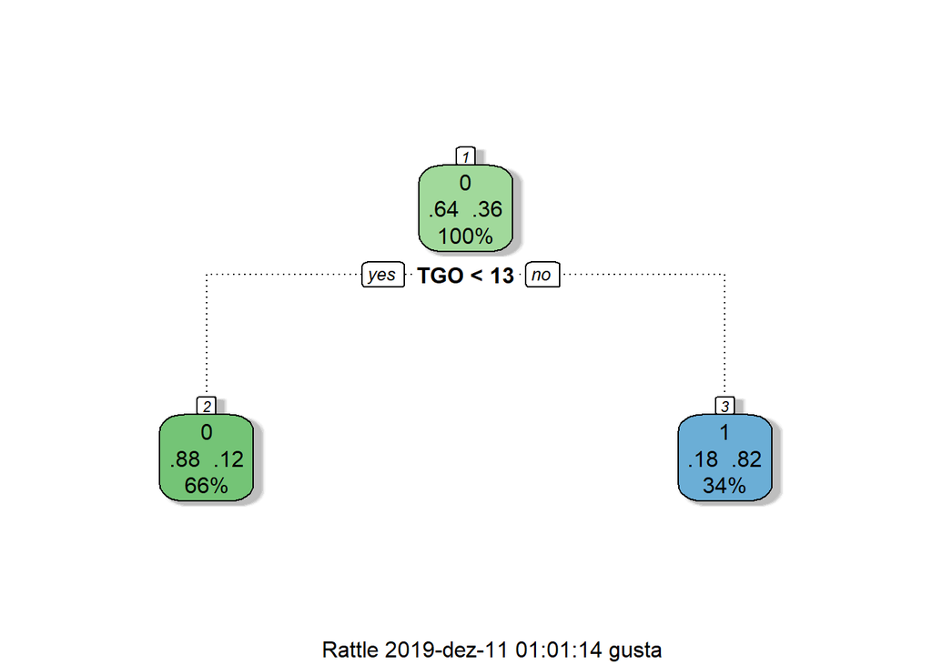

```r
require(rpart)
require(rattle)
dados_primeira_obs=dados2  %>% mutate(Plaquetas=log2(Plaquetas),Leucocitos=log2(Leucocitos),
                                       TGO=log2(TGO),TGP=log2(TGP)) %>% select(-dt_inic) %>% group_by(pac) %>% filter(dt_sup==min(dt_sup))

Arvore = rpart(TARGET~ Ht + TGO + ICTERICIA  +Plaquetas, data=dados_primeira_obs,maxdepth=6,method='class')
fancyRpartPlot(Arvore)
```

```r
t_pred <- predict(Arvore,dados_primeira_obs)[,1]


confusionMatrix(ifelse(t_pred<.5,1,0) %>% as.factor,dados_primeira_obs$TARGET %>% as.factor,positive='1')
```

```
## Confusion Matrix and Statistics
##
##           Reference
## Prediction  0  1
##          0 58  8
##          1  6 28
##
##                Accuracy : 0.86
##                  95% CI : (0.776, 0.921)
##     No Information Rate : 0.64
##     P-Value [Acc > NIR] : 8.06e-07
##
##                   Kappa : 0.692
##
##  Mcnemar's Test P-Value : 0.789
##
##             Sensitivity : 0.778
##             Specificity : 0.906
##          Pos Pred Value : 0.824
##          Neg Pred Value : 0.879
##              Prevalence : 0.360
##          Detection Rate : 0.280
##    Detection Prevalence : 0.340
##       Balanced Accuracy : 0.842
##
##        'Positive' Class : 1
##
```